[figure not shown]

[figure not shown]

[figure not shown]

# Proceso Patentes Comerciales

El Proceso de Patentes de la Municipalidad de Santa Ana tiene por objetivo autorizar, controlar y fiscalizar las actividades comerciales en el Cantón, en cumplimiento con la normativa vigente. Es un proceso que forma parte de Gestión Financiera y Tributaria y está subordinado a la Alcaldía Municipal.

**Gestiones que realiza el Proceso de Patentes:**

- Generar anualmente el cálculo de la base imponible según el proceso de declaración juradas de los contribuyentes del impuesto de patentes.
- Resolver los reclamos administrativos y denuncias que presenten los contribuyentes del impuesto de patentes o cualquier ciudadano(a), relacionadas con actividades comerciales en el Cantón.
- Verificar y resolver las solicitudes recibidas para el otorgamiento de licencias municipales.
- Trasladar al proceso de Asesoría Legal la resolución de los recursos de revocatoria con apelación en subsidio.
- Gestionar las publicaciones en el diario oficial “La Gaceta” sobre traspasos de licencias de licor.
- Coordinar los procesos de clausura de actividades económicas y comerciales que no cumplan con la normativa vigente.

**Información general:**

**¿Cómo se determina el impuesto de la patente o licencia comercial?**

El impuesto es determinado según la Ley de Impuestos Municipales del Cantón de Santa Ana N°7245, toda actividad debe cancelar su impuesto, para ello: Artículo 2.- El impuesto de patentes se pagará durante el tiempo en que se haya tenido abierto el establecimiento o se haya ejercido el comercio en forma ambulante y durante el tiempo en que se haya poseído la licencia, aunque la actividad no se hubiera realizado. Para la determinación del impuesto se dispone:

Artículo 3.- Salvo los casos en que esta Ley determine un procedimiento diferente para fijar el monto del impuesto de patentes, se establecen como factores determinantes para la imposición: la renta líquida gravable y las ventas o los ingresos brutos anuales que perciban las personas físicas o jurídicas afectas al impuesto, durante el período fiscal anterior al año en que se da la imposición.

Artículo 4.-La renta líquida gravable y las ventas o los ingresos brutos anuales, determinarán el monto del impuesto de patente que le corresponde pagar a cada contribuyente, de conformidad con el párrafo primero del artículo 1.

**¿Cómo se solicita una patente o licencia comercial?**

1. Solicitar el uso de suelo para la actividad que se desea explotar, para ello deberá ingresar a la página web de la Municipalidad www.santaana.go.cr y proceder a registrarse como un usuario. Luego proceder a ingresar a su perfil y dirigirse a los trámites digitales y seguir los pasos para uso de suelo. Este trámite tiene un costo de ¢2400.
2. Requisitos necesarios para la presentación de la patente, deberá ingresar a la sección “Formularios” o mediante el siguiente enlace https://www.santaana.go.cr/index.php/tramites Allí buscará la opción de Solicitud de Patente, y podrá conocer los requisitos y descargar el formulario de solicitud y la autorización del dueño de la propiedad.
3. Solicitar cita para gestión de solicitud de patente nueva. Deberá llamar al 2582-7200 y gestionar una cita con la Plataforma de Servicios para la presentación de la documentación y con ello iniciar el proceso del trámite (Durante Pandemia COVID-19).

En las siguientes pestañas usted encontrará información relevante sobre una muestra aleatoria correspondiente a la distribución de las Licencias Comerciales del cantón, presentadas en un mapa, gráficas y tablas.

# Mapa

### Muestra de distribución de patentes comerciales en Santa Ana

[interactive chart not shown]

# Gráficos

### Gráfico 1

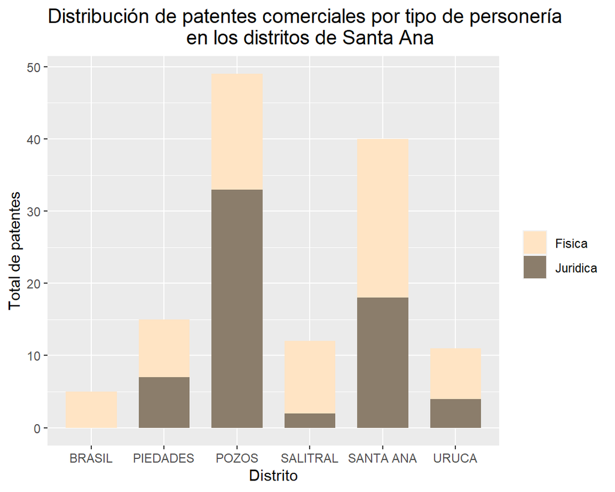

### Gráfico 2

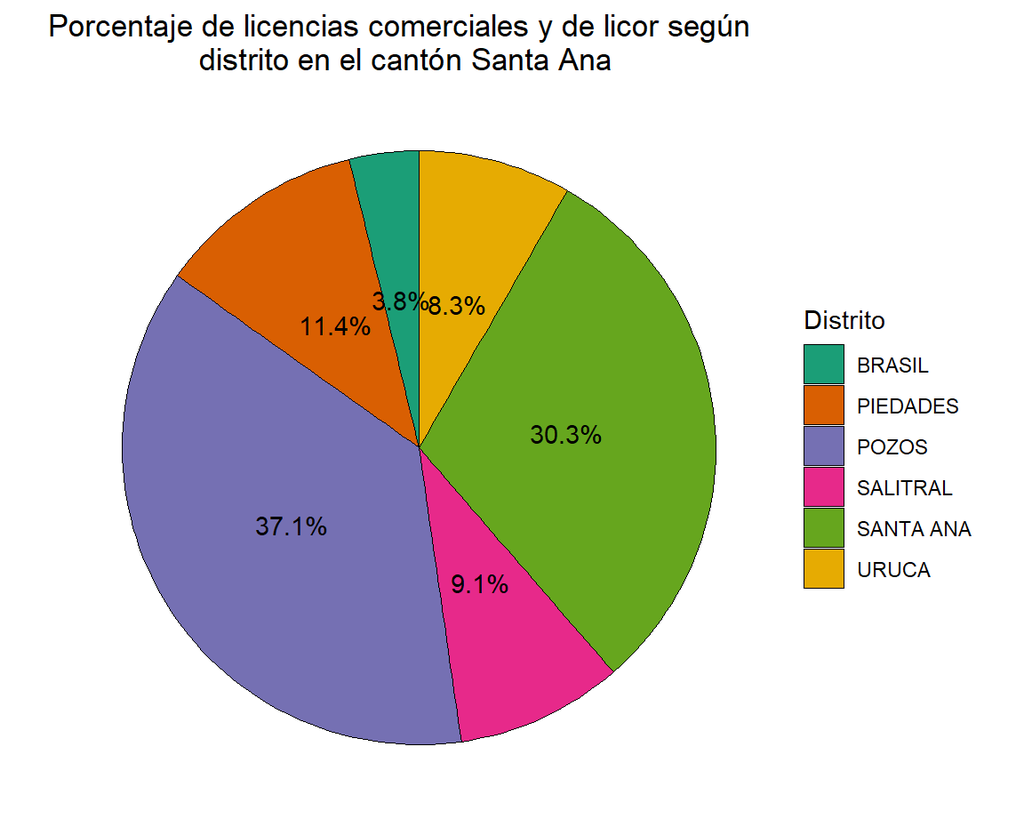

### Gráfico 3

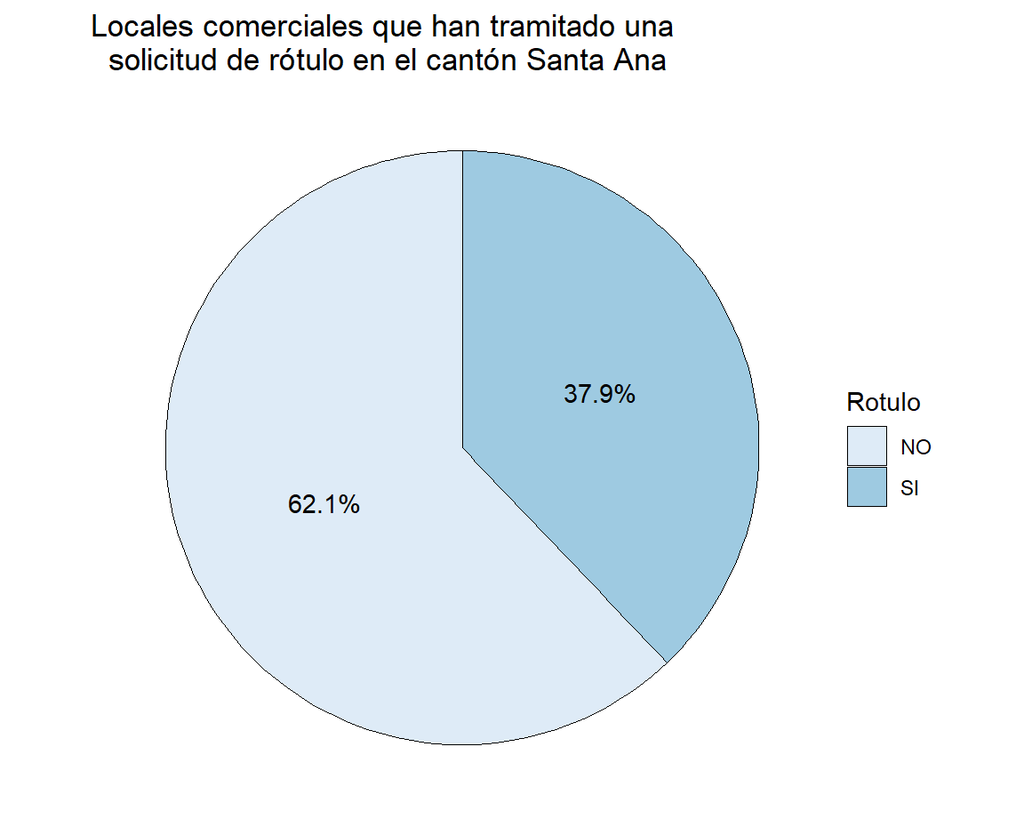

# Tabla

|  | N_patente | Aprobacion | Nombre_comercio | Permiso_salud | Rotulo | N_finca | Tipo_persona | Direccion_ | Distrito |
| --- | --- | --- | --- | --- | --- | --- | --- | --- | --- |
| 1 | 207 | 18/11/2004 | BOLSA NACIONAL DE VALORES | 3467-2019 | SI | 25418 | Juridica | POZOS, PARQUE EMPRESARIAL FORUM # 1, FILIAL # 1-A-3. | POZOS |
| 2 | 203 | 25/10/2005 | TELEDOLAR SANTA ANA | 203 | NO | 14130 | Juridica | CENTRO COMERCIAL SANTA ANA 2000, LOCAL # 43. | POZOS |
| 3 | 173 | 26/4/1998 | BANCO HSBC | 173 | NO | 605106 | Juridica | POZOS, DIAGONAL AL DEPOSITO EL LAGAR. | POZOS |
| 4 | 170 | 17/2/2003 | BAC SAN JOSE | 170 | NO | 69880 | Juridica | POZOS, CONDOMINIO VISTANA ESTE, FILIAL # 1-A. | POZOS |
| 5 | 22 | 11/1/2006 | AGRO SALITRE | 22 | NO | 125725 | Juridica | SANTA ANA, CENTRO, DE RICESA 100 ESTE. | SANTA ANA |
| 6 | 488 | 13/10/1986 | TALLER DE ARTESANIA | 488 | SI | 305203 | Fisica | COSTADO OESTE DE LA INTERSECCION DE AVENIDA 16 CON CALLE 11. | SANTA ANA |
| 7 | 717 | 16/2/2001 | DISENIOO EN MADERA | 717 | NO | 334030 | Fisica | SANTA ANA CENTRO, DE LA MUNICIPALIDAD, 250 OESTE. | SANTA ANA |
| 8 | 305 | 9/9/1991 | CERAMICA | 305 | SI | 301376 | Fisica | URUCA, DEL COLEGIO 115 NORTE Y 29 ESTE. | URUCA |
| 9 | 125 | 6/1/1992 | CERAMICA PAUL | 125 | NO | 284975 | Fisica | SANTA ANA, ALTO DE LAS PALOMAS, FRENTE AL HOTEL ALTA. | SANTA ANA |
| 10 | 575 | 9/10/2000 | CERAMICA SANTA ANA | 575 | NO | 266606 | Fisica | SANTA ANA, CENTRO, DEL BANCO POPULAR 350 OESTE. | SANTA ANA |

[output cut: 122 more lines]